# Prosper loan data

## by by Hassan Reda

## Investigation Overview

I'm most interested in seeing how the occupation,original loan amount, stated monthly income features correlate with each other to better predict the loan status of a loan.

I expect some features such as borrower APR, Home ownership, no of credit lines,revolving credit balance and total trades to have an effect on the correlation.

## Dataset Overview

There are 9228897 cells in the dataset with 113937 rows and 81 columns, most columns contain numeric variables.

## Distribution of loan amounts

The is non uniformal with a peak at 4k usd and many frequency spikes at multiples of 5k usd, plotting on a log scale and removing outliers

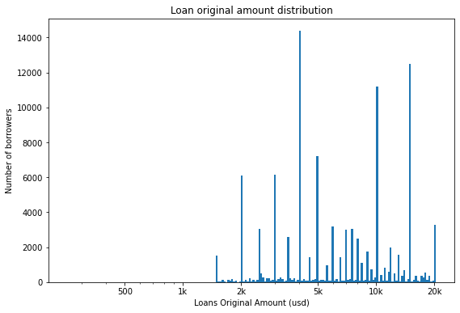

## Occupation and Loan amount

Student loans combined compose the biggest sole borrower type. Most Occupations have average loans that are less than 5k and close in value while some occupations such as 'judge' had an average over 10k usd.

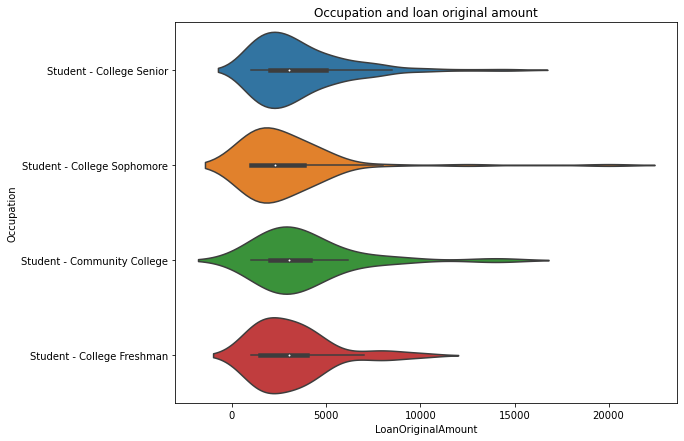

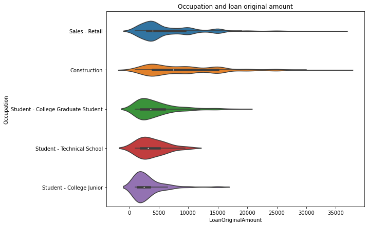

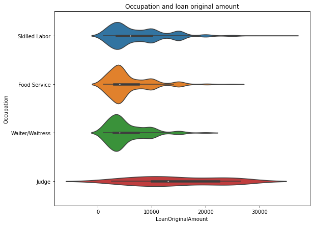

## Distribution of loan status

Removing "current" loan status as it is not informative. The plot shows how loans that are not delivered compose a big percentage of the total loans

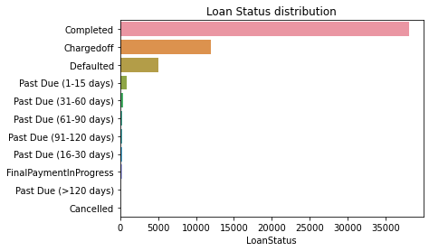

## Occupation and loan status

The figure shows that there is a wide variety between borrowers jobs and not succeeding in delivering loans payments, highest Occupations would be (other,professional,sales-commission,sales-retail) it is advisable not to use "other" and "professional" occupations as they would themselves include different occupations aswell as the "nan" occupation.

1-Most borrowers who work in sales get chargedoff but their majority don't get defaulted.

2-Although the number of borrowers who get defaulted are less than ones who are chargedoff but they are both correlated in the same occupation.

3-Some occupations such as "Dentist" and "Construction" didn't get chargedoff while other occupations as "Attorney" and "biologist" didn't get defaulted, Judge had nan values for both statuses and didn't get displayed.

4-Most occupations that get defaulted and charged off are of an unstable nature and would likely be jobs that depends on gigs or short contracts.

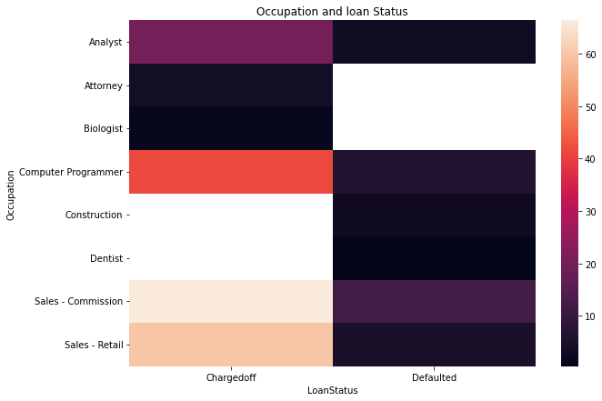

## Occupation, LoanStatus and Loan Original Amount

While the dept to income plots has a direct effect on the type of distribution a plot would have.

This indicates that the initial expectations that monthly income or loan amounts would have a correlation with loan status was wrong but instead the data shows that dept to income ratio has correlation with loan status that is different between each occupation and another There is a variety between plots maximum and minimum values for all facetgrids.

this variety between some occupations' distributions and commonality between others' while maintaining unique frequency spikes and peaks could be met with creating sets from this plot with each set containing occupations that have common distributions with taking notice the different peaks and medians as 2 or 3 values that distinguish each occupation inside it's set.

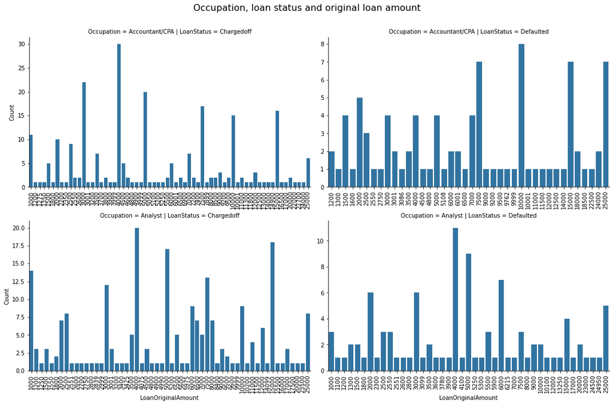

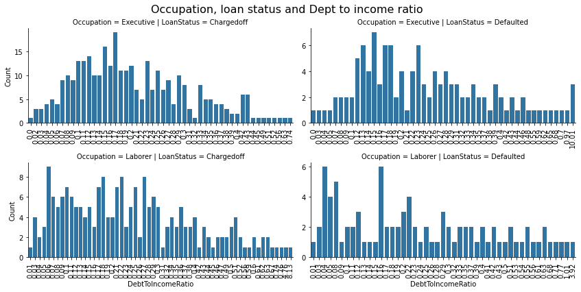